# Range and depth dependence

When describing underwater environments, we often need to work with quantities that vary with position. Some quantities are constant, while others may vary with depth, range, or 3D position (e.g. sound speed profile, bathymetry, etc). We introduce a consistent representation of *fields* to help formalize position-dependent quantities.

## Interface

Fields that do not vary with position are considered constant, and are represented by scalars. If a field may vary only with depth, but not with horizontal position, it is considered `DepthDependent`. On the other hand, if it may vary with any positional coordinate, it is considered `PositionDependent`. Varying fields are represented by data types that are subtypes of the appropriate abstract type (`DepthDependent` or `PositionDependent`).

```julia
DepthDependent
```

Quantity that may vary with depth, but not with range (`x` or `y` coordinate).

```julia
PositionDependent
```

Quantity that may vary with depth and range (`x`, `y` and/or `z` coordinate).

To get the value of a field at a given position, we use the `value` function:

```
value(q)
value(q, pos)
```

Get the value of the varying quantity `q` at the given position `pos`. `pos` may be specified as a `(x, y, z)` tuple, a `(x, z)` tuple, or a `z` value.

#### Examples

```
value(q)             # get value of a constant quantity
value(q, -10)        # get value of a depth-dependent quantity at z=-10
value(q, (1000,-10)) # get value of a position-dependent quantity at x=1000, z=-10
value(q, (0,0,-10))  # get value of a position-dependent quantity at (0,0,-10)
```

Some propagation models (e.g. ray tracers) also require spatial derivatives of a field. These can be obtained using the `∂` function:

```
∂(q, pos, i)
∂(q, pos, i, j)
```

Get the first derivative `∂q/∂i` or second derivative `∂²q/∂i∂j` of the varying quantity `q` at the given position `pos`, where `i` and `j` are coordinate names (`:x`, `:y` or `:z`). `pos` may be specified as a `(x, y, z)` tuple, a `(x, z)` tuple, or a `z` value.

If a field does not provide analytic derivatives, they are derived from `value()` using automatic differentiation. Fields whose interpolation makes derivatives ill-defined at some points (e.g. knots of a piecewise-linear interpolation) may define derivatives there using the surrounding context (e.g. mean of the adjacent segment slopes).

#### Examples

```
∂(q, -10, :z)          # ∂q/∂z of a depth-dependent quantity at z=-10
∂(q, (1000,-10), :x)   # ∂q/∂x of a position-dependent quantity at x=1000, z=-10
∂(q, -10, :z, :z)      # ∂²q/∂z² at z=-10
```

We can also check if a field is constant or range-dependent:

```
is_constant(q)
```

Return `true` if the quantity `q` is a constant, `false` if it could depend on position.

```
is_range_dependent(q)
```

Return `true` if the quantity `q` may be range-dependent, `false` if it is guaranteed to not depend on `x` or `y` coordinate.

Fields that only vary with depth are neither constant nor range-dependent.

Some propagation models require knowledge of the extreme values of a field. These can be obtained using the `minimum` and `maximum` functions:

```
minimum(q)
```

Get the minimum value of a field quantity `q`.

```
maximum(q)
```

Get the maximum value of a field quantity `q`.

## Implementations

### Constants

Scalars are trivially constant fields:

```julia
let q = 1500
  @show q
  @show is_constant(q)
  @show is_range_dependent(q)
  @show value(q)
  @show value(q, -10)
  @show value(q, (1000, -10))
  @show value(q, (0, 0, -10))
  @show minimum(q)
  @show maximum(q)
end;
```

```
q = 1500
is_constant(q) = true
is_range_dependent(q) = false
value(q) = 1500
value(q, -10) = 1500
value(q, (1000, -10)) = 1500
value(q, (0, 0, -10)) = 1500
minimum(q) = 1500
maximum(q) = 1500
```

They can be used in environmental descriptions. For example, iso-velocity environments can be described using a constant sound speed:

```julia
env = UnderwaterEnvironment(soundspeed=1500)
```

### Sampled fields

Position-dependent fields can be defined using data samples at a set of positions. Values at other positions are obtained by interpolation. The `SampledField()` function creates a sampled field from a set of data samples:

```
SampledField(v; x)
SampledField(v; z)
SampledField(v; x, y)
SampledField(v; x, z)
SampledField(v; x, y, z)
```

Create a sampled field from a data `v` that may depend on position. For 1D fields, the `x` or `z` coordinate is required, and `v` is a vector. For 2D fields, the `x` and `y` coordinates or the `x` and `z` coordinates are required, and `v` is a matrix. For 3D fields, the `x`, `y`, and `z` coordinates are required, and `v` is a 3D array.

Keyword argument `interp` is used to specify the interpolation method. `Linear()` interpolation is supported for 1D, 2D and 3D fields. For 2D and 3D fields, the data must be sampled on a regular grid. For uniformly sampled `1D` fields, `CubicSpline()` interpolation is also supported.

We can understand how to use `SampledField` by looking at some examples. Let’s create an environment with a depth-dependent sound speed profile:

```
q = SampledField(z-varying, 2 samples)
is_constant(q) = false
is_range_dependent(q) = false
value(q, 0) = 1500.0
value(q, -50) = 1510.0
value(q, -100) = 1520.0
value(q, (1000, -50)) = 1510.0
value(q, (0, 0, -50)) = 1510.0
minimum(q) = 1500.0
maximum(q) = 1520.0
```

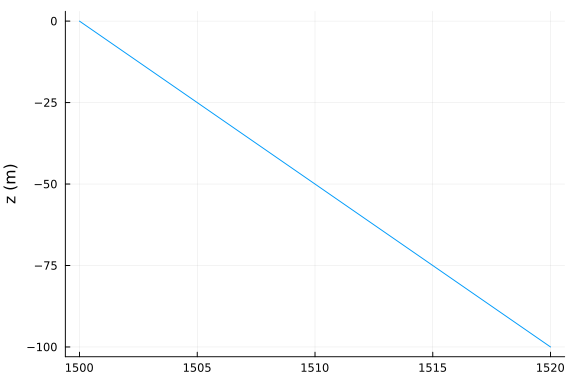

```julia
env = UnderwaterEnvironment(
  soundspeed = SampledField([1500, 1520]; z=[0, -100])
)

let q = env.soundspeed
  @show q
  @show is_constant(q)
  @show is_range_dependent(q)
  @show value(q, 0)
  @show value(q, -50)
  @show value(q, -100)
  @show value(q, (1000, -50))
  @show value(q, (0, 0, -50))
  @show minimum(q)
  @show maximum(q)
  plot(q)
end
```

The default interpolation method is linear, but we can use cubic interpolation by specifying `interp=CubicSpline()`:

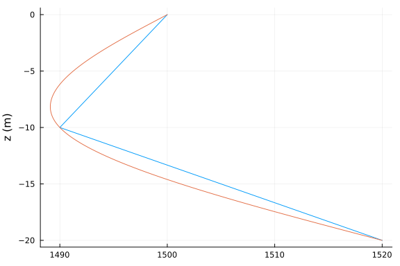

```julia
plot(SampledField([1500, 1490, 1520]; z=0:-10:-20))
plot!(SampledField([1500, 1490, 1520]; z=0:-10:-20, interp=CubicSpline()))
```

Another example is a range-dependent bathymetry:

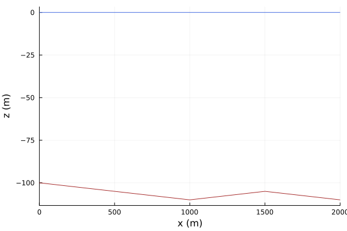

```julia
env = UnderwaterEnvironment(
  bathymetry = SampledField([100, 110, 105, 110]; x=[0, 1000, 1500, 2000])
)

plot(env; xlims=(0,2000))
```

2D and 3D sampled fields can be created by specifying the `x`, `y`, and `z` coordinates. For example, a 2D field can be created using:

```
q = SampledField(xy-varying, 2×2 samples)
is_constant(q) = false
is_range_dependent(q) = true
value(q, (10, 10, 0)) = 1.0
value(q, (10, 10, -10)) = 1.0
minimum(q) = 0.0
maximum(q) = 2.0
```

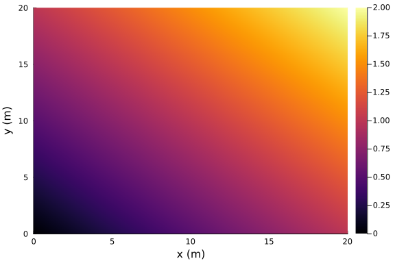

```julia
let q = SampledField([0.0 1.0; 1.0 2.0]; x=[0.0, 20.0], y=[0.0, 20.0])
  @show q
  @show is_constant(q)
  @show is_range_dependent(q)
  @show value(q, (10, 10, 0))
  @show value(q, (10, 10, -10))
  @show minimum(q)
  @show maximum(q)
  plot(q)
end
```

### Custom fields

We may define a custom field type by subtyping `DepthDependent` or `PositionDependent`. For example, we can define a Munk sound speed profile:

```
q = Main.Notebook.MunkSSP()
is_constant(q) = false
is_range_dependent(q) = false
value(q, -1300) = 1500.0
value(q, (100, 100, -1500)) = 1500.4735275294795
minimum(q) = 1500.0
maximum(q) = 1654.0
```

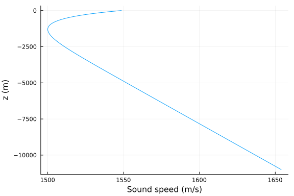

```julia
struct MunkSSP <: UnderwaterAcoustics.DepthDependent end

function (::MunkSSP)(pos)
  ϵ = 0.00737
  z̃ = 2.0 * (-pos.z - 1300.0) / 1300.0
  1500.0 * (1.0 + ϵ * (z̃ - 1 + exp(-z̃)))
end

Base.minimum(::MunkSSP) = 1500.0    # 1.3 km depth
Base.maximum(::MunkSSP) = 1654.0    # 11 km depth (maximum depth of the ocean)

let q = MunkSSP()
  @show q
  @show is_constant(q)
  @show is_range_dependent(q)
  @show value(q, -1300)
  @show value(q, (100, 100, -1500))
  @show minimum(q)
  @show maximum(q)
  plot(q, -11000:0; xlabel="Sound speed (m/s)")
end
```